# Mutating variables

## 1 Introduction

You now know how to keep or drop columns and rows from your dataset. Today you will learn how to modify existing variables or create new ones, using the `mutate()` verb from {dplyr}. This is an essential step in most data analysis projects.

Let’s go!

[figure not shown]

Fig: the mutate() verb.

## 2 Learning objectives

1. You can use the `mutate()` function from the `{dplyr}` package to create new variables or modify existing variables.
2. You can create new numeric, character, factor, and boolean variables

## 3 Packages

This lesson will require the packages loaded below:

```r
if(!require(pacman)) install.packages("pacman")
pacman::p_load(here,
               janitor,
               tidyverse)
```

## 4 Datasets

- In this lesson, we will use two data sets
- The data from the **COVID-19 serological survey** conducted in **Yaounde**, Cameroon.
- A dataset from **a cross-sectional study** conducted to determine the prevalence of **sarcopenia** in the **elderly population (>60 years)** in in Karnataka, **India**.
- **Sarcopenia** is a condition that is **common in elderly people**
- It is characterized by **progressive and generalized loss of skeletal muscle mass and strength**.

```r
yaounde <- read_csv(here::here('data/yaounde_data.csv'))

## a smaller subset of variables
yao <-
  yaounde %>%
  select(date_surveyed,
                          age,
                          weight_kg, height_cm,
                          symptoms, is_smoker) %>%
  rename(age_years = age)

yao
```

| date_surveyed | age_years | weight_kg | height_cm | symptoms | is_smoker |
| --- | --- | --- | --- | --- | --- |
| 2020-10-22 | 45 | 95 | 169 | Muscle pain | Non-smoker |
| 2020-10-24 | 55 | 96 | 185 | No symptoms | Ex-smoker |
| 2020-10-24 | 23 | 74 | 180 | No symptoms | Smoker |
| 2020-10-22 | 20 | 70 | 164 | Rhinitis--Sneezing--Anosmia or ageusia | Non-smoker |
| 2020-10-22 | 55 | 67 | 147 | No symptoms | Non-smoker |
| 2020-10-25 | 17 | 65 | 162 | Fever--Cough--Rhinitis--Nausea or vomiting--Diarrhoea | Non-smoker |
| 2020-10-25 | 13 | 65 | 150 | Sneezing | Non-smoker |
| 2020-10-24 | 28 | 62 | 173 | Headache | Non-smoker |
| 2020-10-24 | 30 | 73 | 170 | Fever--Rhinitis--Anosmia or ageusia | Non-smoker |
| 2020-10-24 | 13 | 56 | 153 | No symptoms | Non-smoker |

[output cut: 961 more lines]

```r
sarcopenia <- read_csv(here::here('data/sarcopenia_elderly.csv'))

sarcopenia
```

| number | age | age_group | sex_male_1_female_0 | marital_status | height_meters | weight_kg | grip_strength_kg | skeletal_muscle_index |
| --- | --- | --- | --- | --- | --- | --- | --- | --- |
| 7 | 60.8 | Sixties | 0 | married | 1.57 | 58 | 8.3 | 6.5 |
| 8 | 72.3 | Seventies | 1 | married | 1.65 | 72 | 13.1 | 9.36 |
| 9 | 62.6 | Sixties | 0 | married | 1.59 | 64 | 8.9 | 6.9 |
| 12 | 72 | Seventies | 0 | widow | 1.473 | 54.5 | 12.3 | 6.1 |
| 13 | 60.1 | Sixties | 0 | married | 1.55 | 47 | 14.6 | 5.49 |
| 19 | 60.6 | Sixties | 0 | married | 1.422 | 64 | 8.7 | 8.07 |
| 45 | 60.1 | Sixties | 1 | widower | 1.68 | 60 | 18.2 | 8.49 |
| 46 | 60.2 | Sixties | 0 | married | 1.8 | 64.6 | 30.7 | 5.99 |
| 51 | 63 | Sixties | 0 | married | 1.6 | 57.8 | 8.1 | 6.21 |
| 56 | 60.4 | Sixties | 0 | married | 1.6 | 71.8 | 14.7 | 7.66 |

[output cut: 229 more lines]

## 5 Introducing `mutate()`

[figure not shown]

The mutate() function. (Drawing adapted from Allison Horst)

- We use `dplyr::mutate()` to create new variables or modify existing variables.
- The syntax is **intuitive**
- `df %>% mutate(new_column_name = what_it_contains)`.
- Let’s see a quick example using `height_cm` from the `yaounde` dataset

Let’s create a data frame, `yao_height`, with just this column, for easy illustration:

```r
yao_height <- yaounde %>% select(_____________)
yao_height
```

[output not shown]

- What if you wanted to **create a new variable** called `height_meters` where heights are converted to meters?
- You can use `mutate()` for this
- With the argument `height_meters = height_cm/100`

```r
yao_height %>%
  mutate(___________________)
```

[output not shown]

- New example !
- Imagine there was a **small error in the equipment** used to **measure respondent heights**
- all heights are 5cm too small
- You want to add 5cm to all heights in the dataset.
- Rather than creating a new variable as you did before, you can **modify the existing variable**

```r
yao_height %>%
  mutate(___________________)
```

[output not shown]

**PRACTICE TIME !**

The `sarcopenia` data frame has a variable `weight_kg`, which contains respondents’ weights in kilograms. Create a new column, called `weight_grams`, with respondents’ weights in grams. Store your answer in the `Q_weight_to_g` object. (1 kg equals 1000 grams.)

```r
# Complete the code with your answer:
Q_weight_to_g <-
  sarcopenia %>%
  _____________________
```

- Hopefully you now see that the mutate function is quite user-friendly.
- In theory, we could end the lesson here…
- But the devil will be in the details

## 6 Creating a variable from scratch (row index)

- Most new variables you create will **reference existing variables** (for example, the `height_meters` variable created above referenced the `height_cm` variable.)
- But in a few special cases you’ll **create variables “from scratch”**, without referring to any others. One example is with the creation of a row index.
- To get such an index, you can use `mutate()` and then generate a sequence of row indices with `1:n()`
- the `n()` function from dplyr returns the number of rows in the data frame

```r
yao_height %>%
  mutate(_______________________)
```

[output not shown]

**PRACTICE TIME !**

Add a variable called `respondent_id` to the `sarcopenia` data frame. The `respondent_id` variable should contain the row number for each row in the data frame. Store the result in the `Q_sarcopenia_resp_id` object.

```r
# Complete the code with your answer:
Q_sarcopenia_resp_id <-
  sarcopenia %>%
  mutate(________________________)
```

Note. The `sarcopenia` data frame has 10 columns, which are unlikely to all fit in your console when you print this data frame. Your new column, `respondent_id` will also probably be hidden.

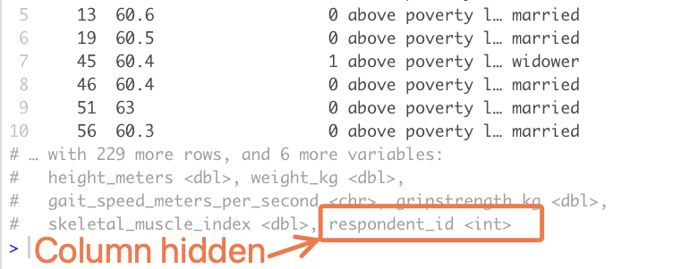

So to see actually see the new column, you can use `View()` to view the entire data frame or `select()` to select the relevant columns.

## 7 Creating a Boolean variable

- You can use `mutate()` to create a Boolean variable to categorize part of your population.
- We create `is_child`
- Which is either `TRUE` if the subject is a child or `FALSE` if the subject is an adult
- We use a condition : `age_years <= 18`, which evaluates whether each age is less than or equal to 18.
- Ages that match that condition (ages 18 and under) are `TRUE`
- Ages (above 18) that fail the condition are `FALSE`.

```r
yao %>%
  select(____________________) %>%
  mutate(____________________)
```

[output not shown]

- Such a variable is useful to, for example, count the number of children in the dataset.
- Let’s count the children after defining them with `mutate()`
- We use the `janitor::tabyl()` function

```r
yao %>%
  mutate(is_child = age_years <= 18) %>%
  tabyl(_______________)
```

[output not shown]

- Let’s see one more example, since the concept of Boolean variables can be a bit confusing.
- The `symptoms` variable reports any respiratory symptoms experienced by the patient
- You could create a Boolean variable, called `has_no_symptoms`
- That is set to `TRUE` if the respondent reported no symptoms

```r
yao %>%
  select(_____________) ___
  ___________________________________________
```

[output not shown]

PRACTICE TIME !

Women with a grip strength below 20kg are considered to have low grip strength.

With a female subset of the `sarcopenia` data frame, add a variable called `low_grip_strength` that is `TRUE` for women with a grip strength < 20 kg and FALSE for other women.

```r
# Complete the code with your answer:
Q_women_low_grip_strength <-
  sarcopenia %>%
  filter(sex_male_1_female_0 == 0) %>% # first we filter the dataset to only women
  mutate(________________________)
```

What percentage of women surveyed have a low grip strength according to the definition above? Enter your answer as a number without quotes (e.g. 43.3 or 12.2).

```r
Q_prop_women_low_grip_strength <- YOUR_ANSWER_HERE
```

## 8 Creating a numeric variable based on a formula

- Now, let’s look at an example of **creating a numeric variable**:
- The **body mass index (BMI)**, which a commonly used **health indicator**.
- The formula for the body mass index can be written as:

$$BMI = \frac{weight (kilograms)}{height (meters)^2}$$

You can use `mutate()` to calculate BMI in the `yao` dataset as follows:

```r
yao %>%
  __________________________

  # first obtain the height in meters
 __________________________

  # then use the BMI formula
  __________________________
```

[output not shown]

Let’s save the data frame with BMIs for later. We will use it in the next section.

```r
yao %>%
  select(weight_kg,  height_cm) %>%
  # first obtain the height in meters
  mutate(height_meters = height_cm/100) %>%
  # then use the BMI formula
  mutate(bmi = weight_kg / (height_meters)^2)
```

```
## # A tibble: 971 × 4
##    weight_kg height_cm height_meters   bmi
##        <dbl>     <dbl>         <dbl> <dbl>
##  1        95       169          1.69  33.3
##  2        96       185          1.85  28.0
##  3        74       180          1.8   22.8
##  4        70       164          1.64  26.0
##  5        67       147          1.47  31.0
##  6        65       162          1.62  24.8
##  7        65       150          1.5   28.9
##  8        62       173          1.73  20.7
##  9        73       170          1.7   25.3
## 10        56       153          1.53  23.9
## # ℹ 961 more rows
```

```r
# yao_bmi <-
#   yao %>%
#   select(weight_kg,  height_cm) %>%
#   # first obtain the height in meters
#   mutate(height_meters = height_cm/100) %>%
#   # then use the BMI formula
#   mutate(bmi = weight_kg / (height_meters)^2)
```

PRACTICE TIME !

**Appendicular muscle mass** (ASM), a **useful health indicator**.

It is the **sum of muscle mass in all 4 limbs**. It can predicted with the following formula, called Lee’s equation:

$$ASM(kg)= (0.244 \times weight(kg)) +
(7.8 \times height(meters)) + (6.6 \times sex) - (0.098 \times
age_years) - 4.5$$

The `sex` variable in the formula assumes that men are coded as 1 and women are coded as 0 (which is already the case for our `sarcopenia` dataset.)

The `- 4.5` at the end is a constant used for Asian populations.

Calculate the ASM value for all individuals in the `sarcopenia` dataset.

```r
# Complete the code with your answer:
Q_asm_calculation <-
  sarcopenia %>%
  mutate(asm = _______________________________________________)
```

## 9 Changing a variable’s type

- In your data analysis workflow, you often need to redefine variable *types*.
- You can do so with functions like `as.integer()`, `as.factor()`, `as.character()` and `as.Date()`
- Within your `mutate()` call.
- Let’s see an example with `as.integer()`, which converts any numeric values to integers:

```r
yao_bmi %>%
  mutate(___________________________)
```

[output not shown]

```r
yao_bmi %>%
  mutate(bmi_integer = as.integer(bmi),
         ________________________________)
```

[output not shown]

PRACTICE TIME !

This should go in a new column called `age_integer`

```r
# Complete the code with your answer:
Q_age_integer <-
  sarcopenia %>%
  mutate(age_integer =  ________________________)
```